# Module 3

2024-07-21

## Introduction

- talking about statistical significance
  - pvalues
  - often many things that you are testing in genomics analysis => multiple comparisons

## Logistic Regression

- case-control study: cases of cardiovascular disease and the controls without it.
  - measure C or T nucleotide in everyone
  - see if there is any correlation between nucleotide and disease outcome.
  - model the outcome (disease / no disease) as a categorical variability.
  - measure log(OR of disease) = intercept + (coeff)( 0 = C, 1 = G)
    - coeff - increase in log odds of outcome given a certain characteristic

Interpreting Logistic Regression Results:

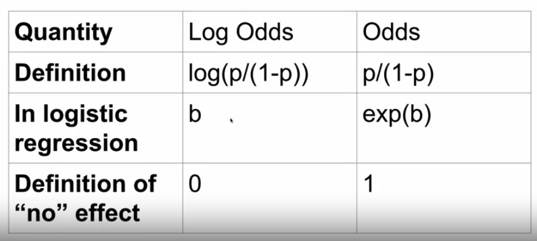

Interpreting Logistic Regression

## Regression for Counts:

- very common situation in genomics: multiple samples/measurements of the same thing
  - ex: reads for a gene
- build a regression model between phenotype and the counts of reads per gene
- in this case, we use generalized linear models
  - poisson variable: better than standard linear regression
  - edgeR and DESeq are better, smooth lines
  - negative binomial model allows you to handle mean and variance seperately

## GLMs in R

```r
# set up
library(devtools)
library(Biobase)
library(snpStats)
library(broom)
library(MASS)
library(DESeq2)
# load in the SNP data
data(for.exercise)
use <- seq(1, ncol(snps.10), 10) # subset
sub.10 <- snps.10[,use]
View(sub.10) # snp (x) by person (y)

# calculate the principal components
xxmat <- xxt(sub.10, correct.for.missing=FALSE)
evv <- eigen(xxmat, symmetric=TRUE)
pcs <- evv$vectors[,1:5]

# reduce dataset size
snpdata = sub.10@.Data
View(snpdata) # snp (x) by person (y)
status = subject.support$cc # status (case or control) for all thousand people
View(status)
snp1 = as.numeric(snpdata[,1]) # first snp for all thousand people

snp1[snp1==0] = NA # code null values for snps

# the logistic regression model
          # y ~ x, family = "binomial"
glm1 = glm(status ~ snp1,family="binomial")
tidy(glm1)
```

```
## # A tibble: 2 × 5
##   term        estimate std.error statistic p.value
##   <chr>          <dbl>     <dbl>     <dbl>   <dbl>
## 1 (Intercept)    0.112     0.232     0.483   0.629
## 2 snp1          -0.101     0.201    -0.502   0.615
```

```r
# logistic regression for having one of the dom allele
snp1_dom = (snp1 == 1)
glm1_dom = glm(status ~ snp1_dom,family="binomial")
tidy(glm1_dom)
```

```
## # A tibble: 2 × 5
##   term         estimate std.error statistic p.value
##   <chr>           <dbl>     <dbl>     <dbl>   <dbl>
## 1 (Intercept)    -0.111     0.193    -0.577   0.564
## 2 snp1_domTRUE    0.125     0.204     0.611   0.541
```

```r
# with the principal comps
glm2 = glm(status ~ snp1 + pcs[,1:5],family="binomial")
tidy(glm2)
```

```
## # A tibble: 7 × 5
##   term        estimate std.error statistic p.value
##   <chr>          <dbl>     <dbl>     <dbl>   <dbl>
## 1 (Intercept)   0.0899     0.234    0.384  0.701
## 2 snp1         -0.0807     0.203   -0.398  0.691
## 3 pcs[, 1:5]1   5.11       2.03     2.52   0.0117
## 4 pcs[, 1:5]2   0.165      2.04     0.0812 0.935
## 5 pcs[, 1:5]3   2.41       2.04     1.18   0.239
## 6 pcs[, 1:5]4  -5.40       2.05    -2.64   0.00835
## 7 pcs[, 1:5]5   0.584      2.04     0.287  0.774
```

```r
# fit many glms at once
glm_all = snp.rhs.tests(status ~ 1,snp.data=sub.10)
slotNames(glm_all)
```

```
## [1] "snp.names" "var.names" "chisq"     "df"        "N"
```

```r
slotNames(glm_all)
```

```
## [1] "snp.names" "var.names" "chisq"     "df"        "N"
```

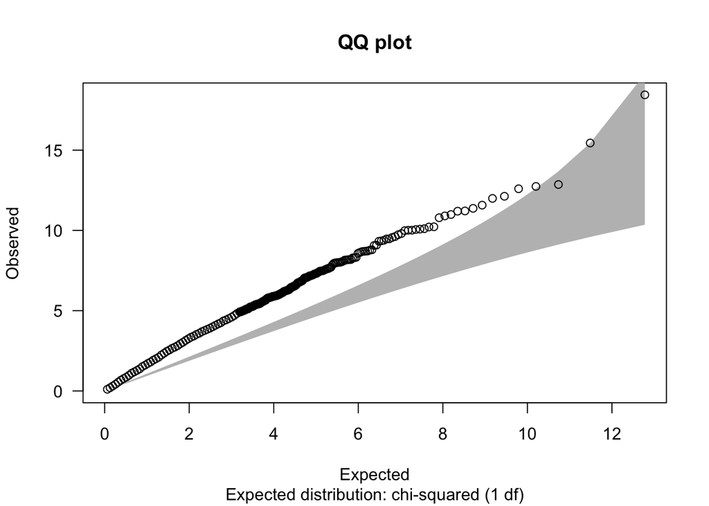

```
##           N     omitted      lambda
## 2851.000000    0.000000    1.657571
```

```r
qq.chisq(chi.squared(glm_all), df = 1)
```

```r
# showed more example, look at the notes
# glm.nb fits a negative binomia model
```

## Inference

- confidence intervals give you an idea of the quantity applicable to the whole population

## Null and alternative hypotheses

- already know all about this
- null: what you would observe if the hypothesis is wrong, if there is no effect
  - when something is not significant, not enough data to reject the null
- variability within groups makes it harder to see differences between them
- t-statistic and t-tests are used commonly

## Comparing Models

- buncha math to compare models, didn’t really take notes because i think there will be a practical

## Calculating Statistics in R

- didn’t take notes sue me im tired i’m just scrolling along with coure notes

## Permutations

- compare control / noncontrol
- permute labels -> get rid of the labels

## PVals + multiple testing

- already know bout this

Was familiar with the other topics already so i didn’t take notes.